# Propuesta de Trabajo Final: Hurtos y Sentimiento Mediático en Bogotá

Primera Entrega (Semana 11) — Taller de Programación en R

Authors

Gabriel Arturo Echeverry Castaño — 201016705

Olga Lucía Ramírez Contreras — 202624900

Sergio Alejandro López Valderrama — 202111932

Juan Esteban Carvajal Cruz — 202614312

Miguelangel Palma — 202621481

Juan José Echeverry — 202616233

Published

October 24, 2026

# 1 Pregunta de Investigación

¿Cómo se relacionan los registros de hurto con el tono de las noticias sobre inseguridad en las 19 localidades urbanas de Bogotá entre 2022 y 2026? Se analizan hurtos a personas, residencias y motocicletas mediante tasas anuales por 100.000 habitantes y se comparan con índices de sentimiento calculados con `sentometrics`.

**Hipótesis:** Las localidades con mayores tasas de hurto reciben coberturas de prensa más frecuentes y con mayor polaridad negativa. No obstante, esta relación presenta divergencias espaciales: las zonas comerciales y céntricas concentran una atención periodística desfavorable que supera la proporción esperada por su población residente. El alcance del trabajo es descriptivo y evalúa la correspondencia entre estadísticas oficiales y contenido noticioso, reconociendo que la agenda de los medios no sustituye las encuestas de percepción ciudadana.

# 2 Motivación

El hurto condiciona decisiones económicas cotidianas: la localización de comercios, las rutas de transporte y el uso del espacio público. Sin embargo, la atención de los medios no siempre sigue el ritmo de las denuncias en las estaciones de policía. Cuando la prensa concentra su cobertura en ciertos sectores, altera la reputación barrial e influye en la demanda ciudadana por recursos de vigilancia. Determinar si las noticias reflejan la criminalidad registrada o si introducen sesgos territoriales permite evaluar el papel de los medios en el debate de seguridad. Este trabajo cruza estadísticas delictivas y demográficas oficiales con minería de texto en prensa local, aportando evidencia empírica reproducible para analizar estas brechas espaciales en Bogotá.

# 3 Descripción de los Datos

El estudio combina tres fuentes públicas: 1. *Secretaría Distrital de Seguridad (SDSCJ):* registros de delitos de alto impacto por localidad (2022–2026). 2. *Secretaría Distrital de Salud (SDS):* proyecciones de población por localidad para calcular tasas por 100.000 habitantes. 3. *Google News RSS:* 3.916 artículos de prensa regional y nacional sobre delincuencia en Bogotá (2022–2026).

La base agregada es un panel de localidad por año con 95 observaciones (19 localidades urbanas durante 5 años), mientras que las noticias se conservan como microdatos individuales. Las variables incluyen denuncias y tasas de hurto (discretas y continuas), volumen noticioso, puntaje de polaridad léxica y proporción de notas negativas. Los archivos se estructuran en formatos Parquet y GeoJSON, vinculados por código oficial de localidad y año.

# 4 Plan General del Manejo de los Datos y Metodología

El procedimiento incluye cuatro etapas reproducibles: 1. *Ingesta y almacenamiento:* descarga automatizada de registros abiertos y consolidación en Parquet para optimizar memoria. 2. *Depuración y homologación:* exclusión del área rural de Sumapaz, estandarización de nombres de las 19 localidades urbanas y limpieza textual (remoción de etiquetas HTML, cuñas publicitarias y avisos de navegación). 3. *Minería de texto:* cómputo de sentimiento proporcional por noticia mediante `sentometrics` y el léxico NRC en español, calculando el balance neto entre términos positivos y negativos. 4. *Clasificación territorial:* cálculo de tasas por 100.000 habitantes residentes y segmentación mediante *K-means* (seleccionando grupos según el coeficiente de silueta), combinando delincuencia registrada y polaridad mediática.

El análisis incorpora la distorsión que genera la población flotante en las tasas céntricas y sintetiza las relaciones espaciales en una aplicación interactiva en Shiny.

# 5 Análisis Preliminar de Datos y Storytelling

El panel reúne 95 observaciones anuales por localidad entre 2022 y 2026, junto con 3.916 artículos de prensa depurados. La Table 1 resume las variables centrales.

Table 1: Estadísticas descriptivas consolidadas: delitos, demografía y métricas de prensa (2022–2026)

| Variable | Media | Mediana | Desv. Est. | Mínimo | Máximo |
| --- | --- | --- | --- | --- | --- |
| Tasa hurto a personas (por 100k hab.) | 2910.71 | 1602.74 | 2905.03 | 410.33 | 13348.28 |
| Tasa hurto a residencias (por 100k hab.) | 108.44 | 90.45 | 72.02 | 27.73 | 398.13 |
| Tasa hurto a motocicletas (por 100k hab.) | 68.19 | 60.00 | 43.16 | 11.45 | 291.23 |
| Volumen de noticias (por localidad-año) | 41.22 | 39.00 | 21.46 | 5.00 | 88.00 |
| Índice de sentimiento neto (sentometrics) | -0.02 | -0.01 | 0.02 | -0.06 | 0.05 |
| Proporción de noticias negativas (%) | 47.83 | 46.88 | 12.73 | 7.14 | 87.50 |

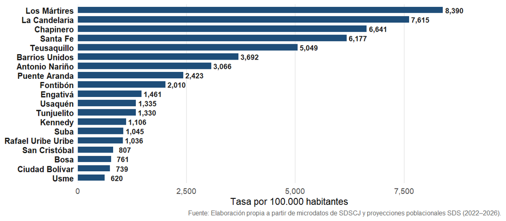

Figure 1: Tasa promedio anual de hurto a personas por localidad en Bogotá (2022–2026). Expresada en hechos denunciados por cada 100.000 habitantes.

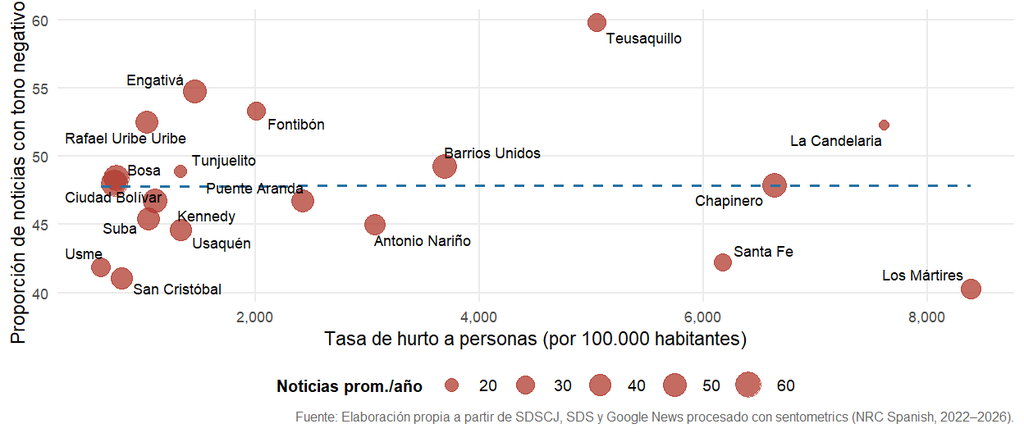

Figure 2: Contraste entre criminalidad registrada (tasa de hurto a personas) y porcentaje de cobertura periodística con tono negativo (2022–2026).

La evidencia preliminar sugiere que la atención de la prensa responde tanto a la gravedad del hecho como a la notoriedad del sector, antes que a la tasa matemática de criminalidad. Para la entrega final, se empleará un algoritmo de *K-means* que agrupe las localidades según sus tres tasas de hurto y sus indicadores de sentimiento. Este ejercicio permitirá distinguir territorios con alta incidencia y alta cobertura de aquellos con estigmatización mediática no correspondida por sus denuncias, sirviendo de base para la herramienta interactiva en Shiny.

# 6 Referencias

- Ardia, D., Bluteau, K., Borms, S., & Boudt, K. (2021). The R Package sentometrics to Compute, Aggregate and Predict with Textual Sentiment. *Journal of Statistical Software*, 99(2), 1–40.
- Mohammad, S. M., & Turney, P. D. (2013). Crowdsourcing a Word-Emotion Association Lexicon. *Computational Intelligence*, 29(3), 436–465.
- Secretaría Distrital de Seguridad, Convivencia y Justicia — SDSCJ. (2026). *Delito de Alto Impacto. Bogotá D.C.* Portal Datos Abiertos Bogotá.
- Secretaría Distrital de Salud — SDS. (2026). *Pirámide Poblacional y Proyecciones Demográficas 2005–2035*. Alcaldía Mayor de Bogotá.